# Go to Empirical null hypothesis

### There are different more complex clustering methods I am using here.

#### Not optimal approaches (since it doesn't recognize the same pattern starting at position 0 or at position 15), but still try...:

1. PCA on original ohe_data (Don't understand the results, but the explained variance of each component (for 2 components) is up to 5%.
2. PCA on original positive set (ohe_data).
3. KMeans over the whole sequence

#### More ratoinal approaches

1. KMeans using the frequencies of most predicted aminoacids on each sequence
2. Instead of using the most frequent aminoacids, use a ohe of frequencies of classes of aminoacids (e.g [hyrdroph][charged][neutral]...)
3. Autoencoder followed by kmeans?
4. Autoencoders using the same rationale as in 5

### 1.

```python
from sklearn.decomposition import PCA

# apply pca to 2 components
pca = PCA(n_components=2).fit(ohe_data.reshape(ohe_data.shape[0], 30*23))

# plot
plt.figure(figsize=(5,5))
plt.grid()
plt.title('explained_variance =' + str((100* np.round(pca.explained_variance_ratio_,2)).astype(int)) + '%')
plt.scatter(pca.components_[0], pca.components_[1])
```

[output not shown]

### 2.

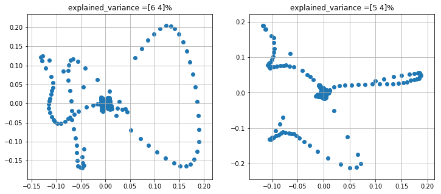

```python
from sklearn.decomposition import PCA

idx_1 = np.where(data.TAD==1)[0]
idx_0 = np.where(data.TAD==0)[0]

# apply pca to 2 components
pca1 = PCA(n_components=2).fit(ohe_data[idx_1].reshape(len(idx_1), 30*23))
pca0 = PCA(n_components=2).fit(ohe_data[idx_0].reshape(len(idx_0), 30*23))

# plot
plt.figure(figsize=(12,5))
plt.subplot(121)
plt.grid()
plt.title('explained_variance =' + str((100* np.round(pca1.explained_variance_ratio_,2)).astype(int)) + '%')
plt.scatter(pca1.components_[0], pca1.components_[1])

plt.subplot(122)
plt.grid()
plt.title('explained_variance =' + str((100* np.round(pca0.explained_variance_ratio_,2)).astype(int)) + '%')
plt.scatter(pca0.components_[0], pca0.components_[1]);
```

```python
from sklearn.decomposition import PCA

# apply pca to 2 components
pca = PCA(n_components=2).fit(ohe_data.reshape(ohe_data.shape[0], 30*23))

# plot
plt.figure(figsize=(5,5))
plt.grid()
plt.title('explained_variance =' + str((100* np.round(pca.explained_variance_ratio_,2)).astype(int)) + '%')
plt.scatter(pca.components_[0], pca.components_[1])
```

[output not shown]

### 3.

```python
from sklearn.cluster import KMeans

_inertias = []
for n_clusters in range(2,10):
    km = KMeans(n_clusters=n_clusters, random_state=2).fit(argmaxs)
    _inertias.append(km.inertia_)

plt.figure(figsize=(5,5))
plt.grid()
plt.plot(range(2,10), _inertias)
plt.title('how many clusters from saturated mutagenesis')
plt.ylabel('explained variance')
plt.xlabel('# clusters');

km = KMeans(n_clusters=4, random_state=8).fit(argmaxs)
reduced_index[np.where(km.labels_==3)]
```

[output not shown]